# usingjohnwithnewcode

Let’s try this out with john’s data at time point 18, and notperform the centering in advnace.

Critically, I’m going to use the batch corrected data from John to avoid having to add back in the intercept term The weights don’t make a sizeable difference, and the modeling with mean included is difficult if we need to remove the covariates for whom the mean will be partially assumed.

REad in the batch corrected data. This includes the mean gene expression for each gene:

```r
batchcorrectdata=read.table("~/Dropbox/oldnobaseline/john/s1table.txt",header = T,stringsAsFactors = F)[,-c(1,2)]
anno=read.table("~/Dropbox/oldnobaseline/john/annotation.txt",header=T)
library('limma')
```

Prepare the factors for use in the linear model.

```r
groups <- anno[, c("ind", "bact", "time", "extr", "rin")]
groups$bact <- gsub("\\+", "plus", groups$bact)
groups$ind <- factor(groups$ind)
groups$bact <- factor(groups$bact, levels = c("none", "Rv", "Rvplus", "GC",
                                              "BCG", "Smeg", "Yers", "Salm",
                                              "Staph"))
groups$time <- factor(groups$time, levels = c(4, 18, 48))
groups$extr <- factor(groups$extr)
head(groups)
```

```
##    ind bact time extr rin
## 1 M372 none    4    1 9.8
## 2 M375 Smeg   48    1 9.3
## 3 M373   GC   18    1 9.0
## 4 M374  BCG   48    1 8.8
## 5 M375 none    4    1 8.8
## 6 M372 Smeg   48    1 9.5
```

Prepare model_matrix

```r
design <- model.matrix(~ bact-1, data = groups)
# Clean up names of design matrix
colnames(design) <- gsub("bact", "", colnames(design))
dim(design)
```

```
## [1] 156   9
```

```r
beta_class <- matrix(0, dim(batchcorrectdata)[1], dim(design)[2]);
sebeta_class <- matrix(0, dim(batchcorrectdata)[1], dim(design)[2])
t_class = matrix(0, dim(batchcorrectdata)[1], dim(design)[2])
colnames(beta_class)=colnames(sebeta_class)=colnames(t_class)=colnames(design)

knownsamples=which(groups$time=="18")
colnames(batchcorrectdata)[10]
```

```
## [1] "M376.Rv.4"
```

```r
which(design[10,]==1)
```

```
## Rv
##  2
```

```r
for(k in c(1:9)){

  model_mat_temp <- cbind(design[knownsamples,k]);
  #vsarah <- voom(y[,knownsamples], model_mat_temp)##ccurrent model
  #vsarah2 <- voom(y[,knownsamples], model_mat)###total model
  #vjohn <- voom(y[,knownsamples], design[knownsamples,])###john'sdesign
  #limma.obj <- limma::lmFit(vsarah$E, model_mat_temp,weights=vsarah$weights);
  #limma.obj2 <- limma::lmFit(vsarah$E, model_mat_temp,weights=vsarah2$weights);
  #limma.obj3 <- limma::lmFit(vsarah$E, model_mat_temp,weights=johnsweights[,knownsamples]);
  ##ask why not the same as
  l=lmFit(object = batchcorrectdata[,knownsamples],model_mat_temp)
  beta_class[,k] <- as.matrix(l$coefficients[,1]);
  sebeta_class[,k] <- l$sigma*(as.matrix(l$stdev.unscaled[,1]));
  t_class[,k] = (as.matrix(l$coefficients[,1]))/(l$sigma*(as.matrix(l$stdev.unscaled[,1])));
  }

##show that beta_class[j,k] ##roughly## corresponds to the average expression at gene j of samples from class k, without incorporation of weights
j=100
k=2
data=as.matrix(batchcorrectdata[,knownsamples])
mean(data[j,c(which(design[knownsamples,k]==1))])
```

```
## [1] 6.405869
```

```r
beta_class[j,k]
```

```
##       Rv
## 6.405869
```

Now we compute the average for each subgroup of the uncentered read counts at each gene. Here, voom_class_adj will not acutally be adjusted byt the mean.

Check to make sure these are stored properly:

```r
j=8
k=3
lmFit(batchcorrectdata[,knownsamples],design[knownsamples,k])$coefficients[j,1]
```

```
##       x1
## 3.985471
```

```r
beta_class[j,k]
```

```
##   Rvplus
## 3.985471
```

```r
sebeta_class[j,k]
```

```
##   Rvplus
## 1.648426
```

```r
t_class[j,k]
```

```
##   Rvplus
## 2.417743
```

```r
beta_class[j,k]/sebeta_class[j,k]
```

```
##   Rvplus
## 2.417743
```

Now we compute factors on the centered T statistics:

```r
b=read.table("betabatchcorrected.txt")
se=read.table("sebetabatchcorrected.txt")
t=read.table("tbatchcorrected.txt")
```

Now Lchat will be the matrix of contrasts:

```r
R=ncol(b)
lchat=b[,2:ncol(b)]-b[,1]
```

So now, $Lchat$ will represent the differences in observed averages over control, and the variances add.

We can write the maxes to a file:

```r
maxes=lchat[order(apply(lchat,1,max),decreasing = T),][1:1000,]
write.table(maxes,"maxes.txt",col.names = FALSE,row.names = FALSE)
m=read.table("maxes.txt")


index=order(apply(lchat,1,max),decreasing = T)[1:1000]
system('/Users/sarahurbut/miniconda3/bin/sfa -gen maxes.txt -g 1000 -k 5 -n 8 i -o lchatwithE')


factor.mat=as.matrix(read.table("lchatwithE_F.out"))
lambda.mat=as.matrix(read.table("lchatwithE_lambda.out"))

library("ExtremeDeconvolution")
R=9;L=cbind(rep(-1,R-1),diag(1,R-1))
lvlarray=genlvllist(s.j = se[index,],L = L )

R=ncol(lchat);K=3;P=3
init.cov=init.covmat(t.stat=maxes,factor.mat = factor.mat,lambda.mat = lambda.mat,K=K,P=P)
init.cov.list=list()
for(i in 1:K){init.cov.list[[i]]=init.cov[i,,]}
mean.mat=matrix(rep(0,ncol(maxes)*nrow(maxes)),ncol=ncol(maxes),nrow=nrow(maxes))
ydata= maxes ##train on the max like estimates (same as using max ws)
xamp=rep(1/K,K)

xcovar=init.cov.list
fixmean=TRUE
ycovar=lvlarray
xmean=mean.mat
projection=list();for(l in 1:nrow(maxes)){projection[[l]]=diag(1,R)}##no projection in mash because we feed in centered estimates
e=extreme_deconvolution(ydata=ydata,ycovar=ycovar,xamp=xamp,xmean=xmean,xcovar=init.cov.list,fixmean=T,projection=projection)##notice no projection.
true.covs=array(dim=c(K,R,R))
for(i in 1:K){true.covs[i,,]=e$xcovar[[i]]}
pi=e$xamp
max.step=list(true.covs=true.covs,pi=pi)

max.step=deconvolution.em.with.bovy(t.stat = maxes,factor.mat = factor.mat,v.j = lvlarray,lambda.mat = lambda.mat,K = 3,P = 3)

sapply(seq(1:3),function(k){all.equal(as.numeric(max.step$true.covs[k,,]),as.numeric(e$xcovar[[k]]))})
```

```
## [1] TRUE TRUE TRUE
```

```r
###recall e is the output using lvl


covmash=compute.hm.covmat.all.max.step(b.hat = lchat,se.hat = se,t.stat = lchat,Q = 5,lambda.mat = lambda.mat,A = "allmash",factor.mat = factor.mat,max.step = max.step,zero = T,power = 2)$covmat


all.equal(covmash[[2]]/max(diag(covmash[[2]])),max.step$true.covs[1,,]/max(diag(max.step$true.covs[1,,])))
```

```
## [1] TRUE
```

```r
all.equal(covmash[[3]]/max(diag(covmash[[3]])),max.step$true.covs[3,,]/max(diag(max.step$true.covs[3,,])))
```

```
## [1] TRUE
```

```r
all.equal(covmash[[9]]/max(diag(covmash[[9]])),max.step$true.covs[2,,]/max(diag(max.step$true.covs[2,,])))
```

```
## [1] TRUE
```

Now, proceed as always, estimating likelihood and computing posteriors.

```r
A="allmashlvl"
compute.hm.train.log.lik.pen.lvlarray(train.b = lchat,lvlarray= lvlarray,covmat = covmash,A=A,pen=1)

pis=readRDS(paste0("pis",A,".rds"))$pihat
b.test=lchat
se.test=se
  for(j in 1:nrow(lchat)){
    total.quant.per.snp.with.lvlarray(j=j,covmat = covmash,b.gp.hat=lchat,lvlarray = lvlarray,pis,A=A,checkpoint = FALSE)}
```

Let’s check our code:

```r
lvlarray=genlvllist(s.j = se,L = L)
means=read.table("allmashlvlposterior.means.txt")[,-1]
lfsrlvl=read.table("allmashlvllfsr.txt")[,-1]

j=10
arrays=post.array.per.snp.with.lvlmat(j = j,covmat = covmash,b.gp.hat = lchat,lvlmat = lvlarray[[j]])
Ugp1kl=post.b.gpkl.cov(V.gp.hat.inv = solve(lvlarray[[j]]),U.0k.l = covmash[[k]])
mu=post.b.gpkl.mean(b.mle = t(as.vector(lchat[j,])),V.gp.hat.inv = solve(lvlarray[[j]]),U.gp1kl = Ugp1kl)

all.equal(as.numeric(mu),as.numeric(arrays$post.means[k,]))
```

```
## [1] TRUE
```

```r
all.equal(diag(Ugp1kl),as.numeric((arrays$post.covs[k,])))
```

```
## [1] TRUE
```

```r
log.lik.snp=log.lik.func(lchat[j,],V.gp.hat = lvlarray[[j]],covmat = covmash)
log.lik.minus.max=log.lik.snp-max(log.lik.snp)
pis=readRDS("pisallmashlvl.rds")$pihat
exp.vec=exp(log.lik.minus.max)
post.weights=t(exp.vec*pis/sum(exp.vec*pis))
all.equal(as.numeric(post.weights%*%arrays$post.means),as.numeric(means[j,]))
```

```
## [1] TRUE
```

And here, we plot the patterns of sharing:

```
## [1] 451
```

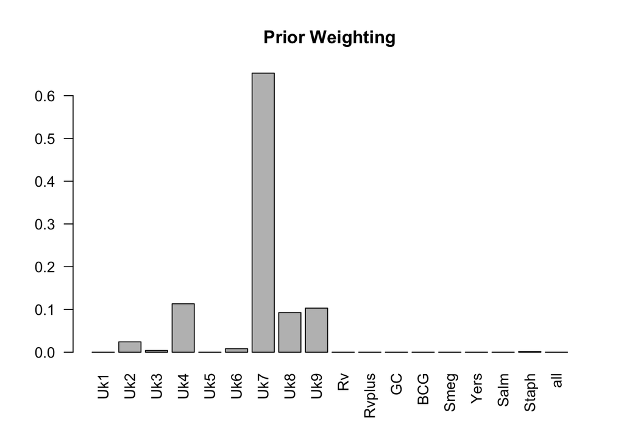

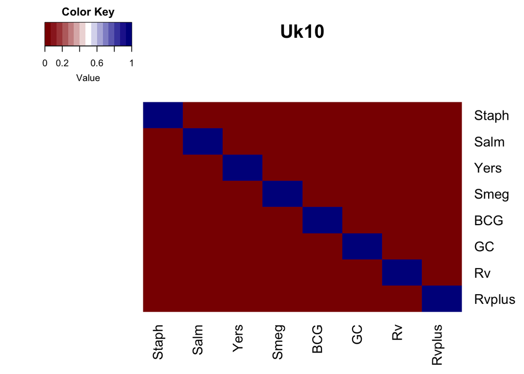

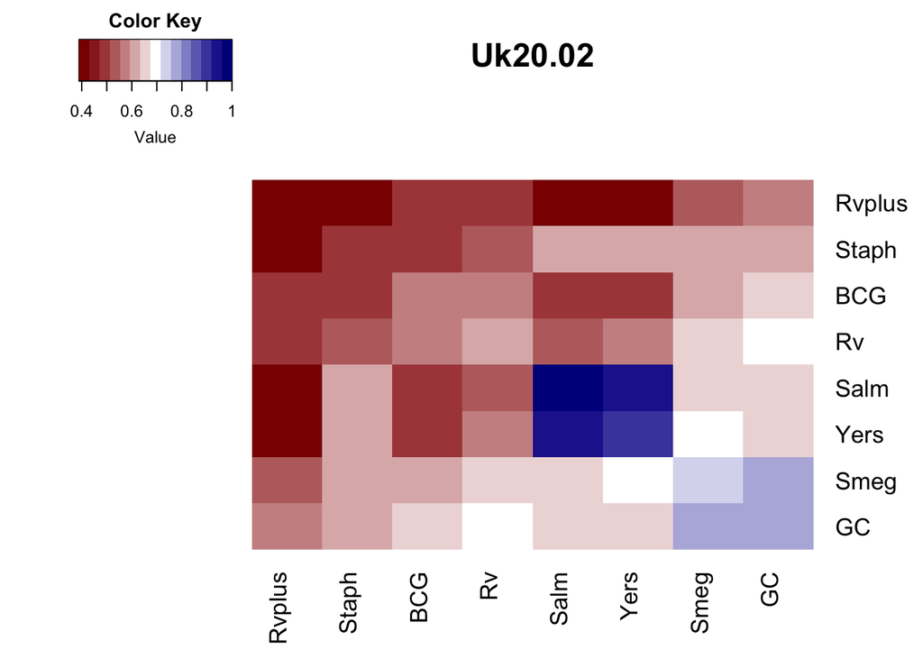

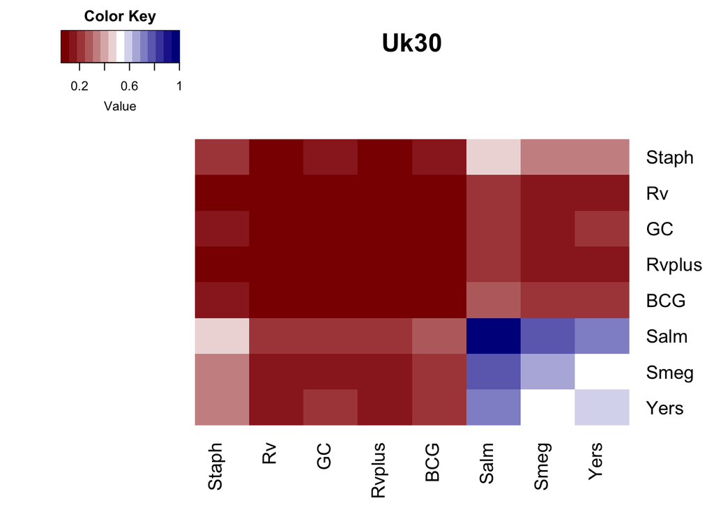

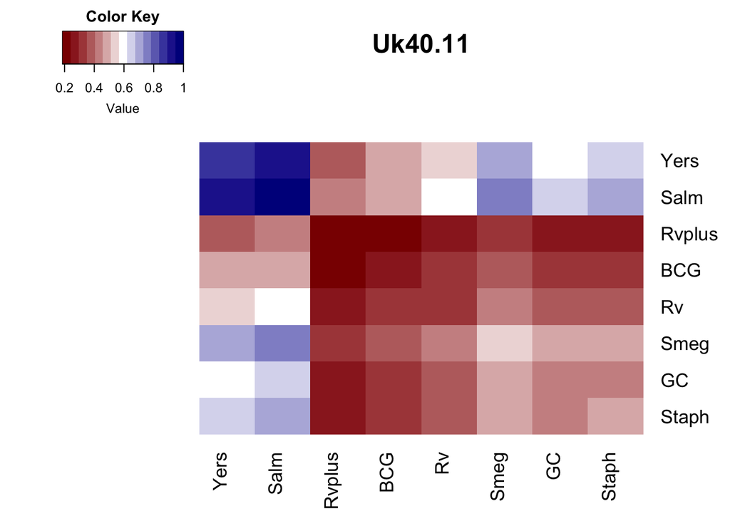

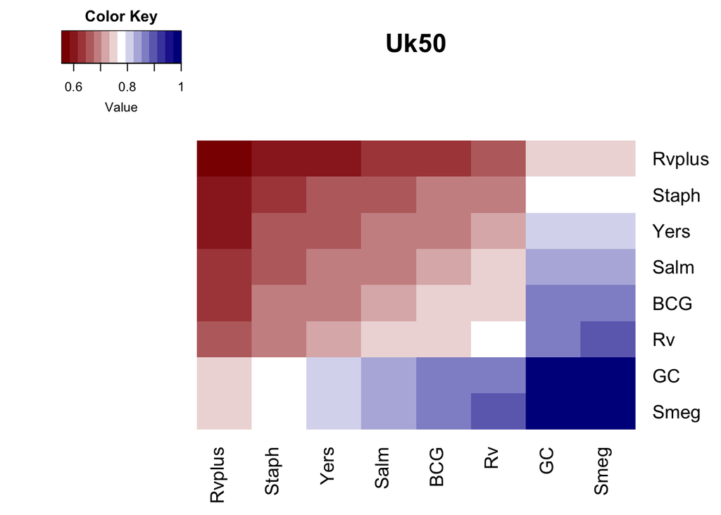

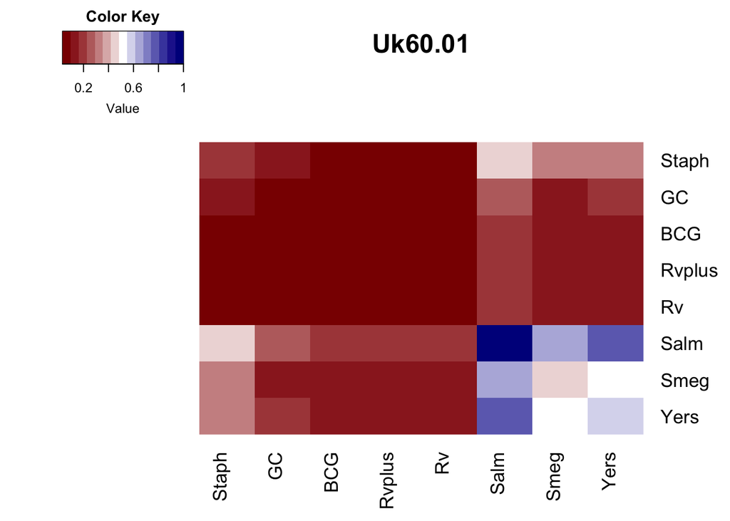

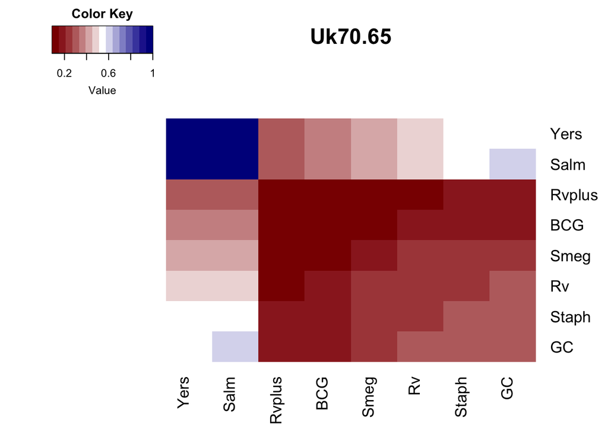

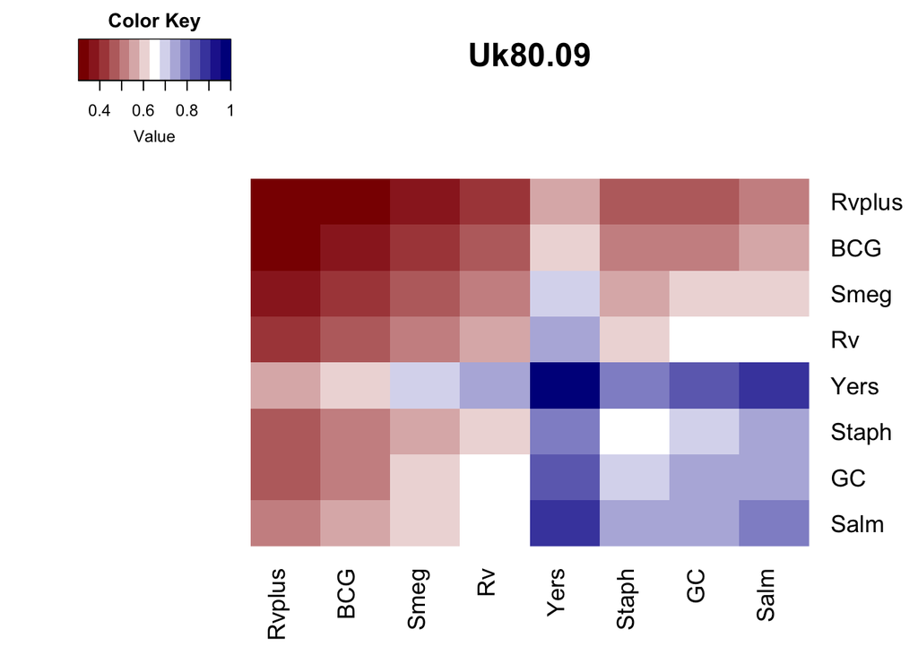

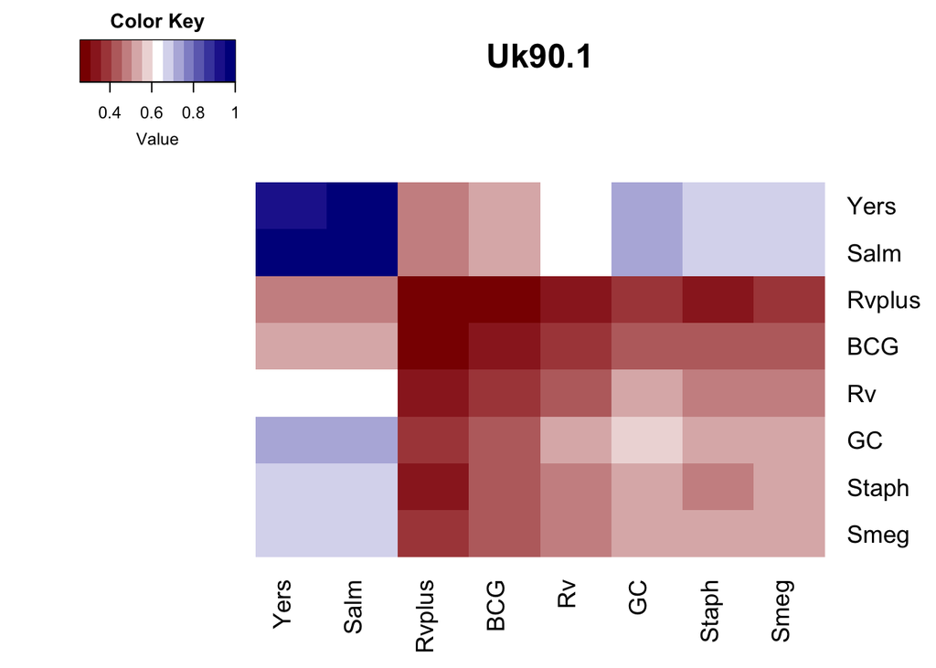

```r
library("mashr")
post.means=read.table("allmashlvlposterior.means.txt")[,-1]
lfsr.mash=read.table("allmashlvllfsr.txt")[,-1]
se.matched=as.matrix(read.table("sebetabatchcorrected.txt"))[,-1]
strain.names=read.table("StrainNames.txt",header = T,stringsAsFactors = F)[,1]
pm.mash.beta=post.means*se.matched
colnames(pm.mash.beta)=colnames(lfsr.mash)=strain.names
lfsr.mash.sig=lfsr.mash[rowSums(lfsr.mash<0.05)>0,]##only 137,223 are significant in at least one subgroup
pm.mash.sig=pm.mash.beta[rowSums(lfsr.mash<0.05)>0,]



library(RColorBrewer)
p=colorRampPalette(brewer.pal(9,"Greens"))(100)
g=colorRampPalette(brewer.pal(9,"Blues"))(100)

signheatmap=compute.sharing.by.sign(lfsr.mash = lfsr.mash.sig,thresh = 0.05,pm.mash.beta = pm.mash.sig)
signheatmap[lower.tri(signheatmap)] <- NA
magheatmap=compute.mag.by.sharing(lfsr.mash = lfsr.mash.sig,thresh = 0.05,pm.mash.beta = pm.mash.sig)
magheatmap[lower.tri(magheatmap)] <- NA


library('colorRamps')
library('corrplot')
library(gplots)
library(ggplot2)

class(signheatmap)
```

```
## [1] "matrix"
```

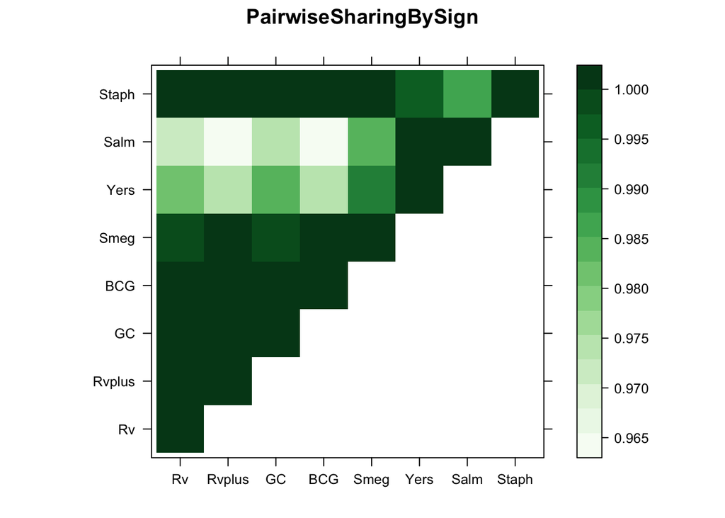

```r
library('lattice')

clrs <- colorRampPalette(rev(c("#D73027","#FC8D59","#FEE090","#FFFFBF",
                               "#E0F3F8","#91BFDB","#4575B4")))(64)
#clrs[63:64] <- "darkviolet"
lat=signheatmap
lat[lower.tri(lat)] <- NA
print(levelplot(lat,col.regions = p,xlab = "",ylab = "",colorkey = TRUE,main="PairwiseSharingBySign"))
```

[figure not shown]

```r
heatmap.2(magheatmap,Rowv=FALSE,Colv=FALSE,
          symm=TRUE,dendrogram="none",density="none",trace="none",#col=redblue,
          col=blue2green,main=paste0("Pairwise Sharing by Magnitude"),
          cexRow=0.6,cexCol=2,cex.main=0.5,#breaks=seq(0.35,1,0.01),
          labCol=NA)
```

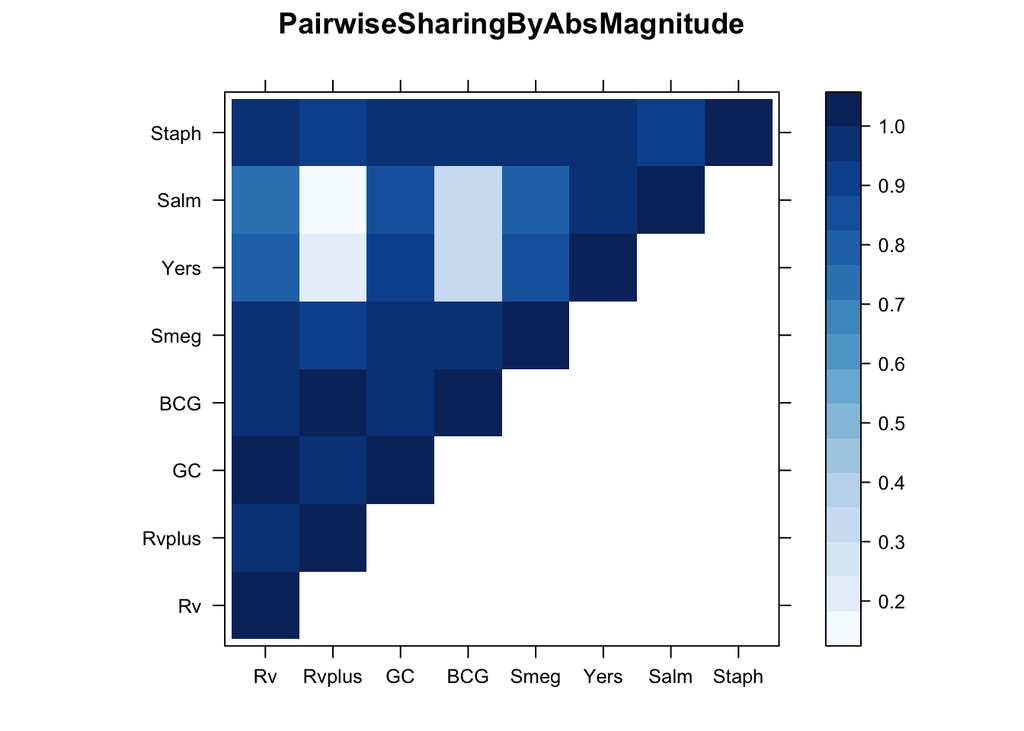

```r
library('lattice')

clrs <- colorRampPalette(rev(c("#D73027","#FC8D59","#FEE090","#FFFFBF",
                               "#E0F3F8","#91BFDB","#4575B4")))(64)
#clrs[63:64] <- "darkviolet"
absmagheatmap=compute.mag.by.sharing(lfsr.mash = lfsr.mash.sig,thresh = 0.05,pm.mash.beta = abs(pm.mash.sig))
absmagheatmap[lower.tri(absmagheatmap)] <- NA
lat=absmagheatmap
lat[lower.tri(lat)] <- NA
print(levelplot(lat,col.regions = g,
                xlab = "",ylab = "",colorkey = TRUE,main="PairwiseSharingByAbsMagnitude"))
```

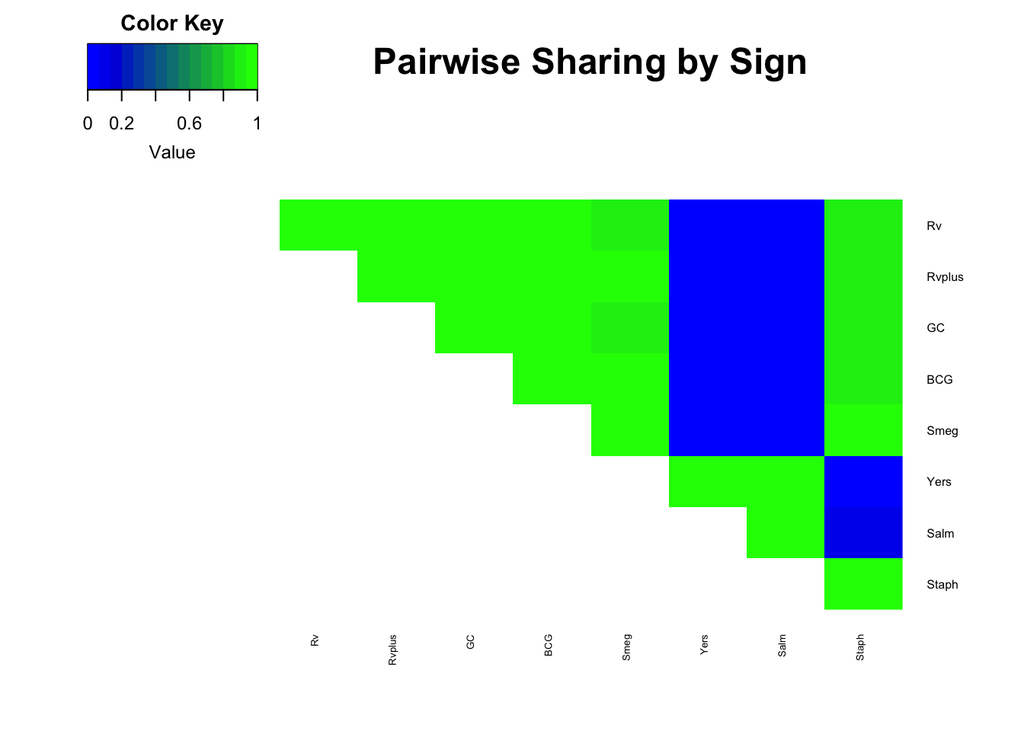

```r
heatmap.2(signheatmap,Rowv=FALSE,Colv=FALSE,
          symm=TRUE,dendrogram="none",density="none",trace="none",#col=redblue,
          col=blue2green,main=paste0("Pairwise Sharing by Sign"),
          cexRow=0.6,cexCol=0.5,cex.main=0.5)
```

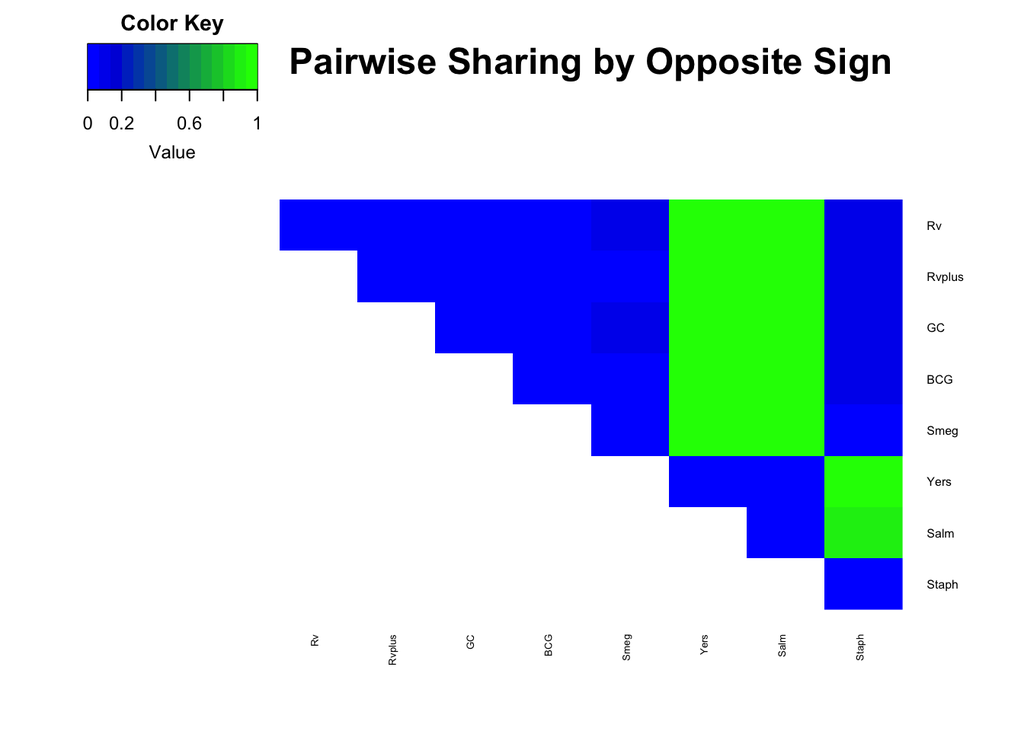

```r
#,breaks=seq(0.7,1,0.01))

heatmap.2(1-signheatmap,Rowv=FALSE,Colv=FALSE,
          symm=TRUE,dendrogram="none",density="none",trace="none",#col=redblue,
          col=blue2green,main=paste0("Pairwise Sharing by Opposite Sign"),
          cexRow=0.6,cexCol=0.5,cex.main=0.5)
```

[figure not shown]

```r
#,breaks=seq(0.7,1,0.01))



absmagheatmap=compute.mag.by.sharing(lfsr.mash = lfsr.mash.sig,thresh = 0.05,pm.mash.beta = abs(pm.mash.sig))
absmagheatmap[lower.tri(absmagheatmap)] <- NA
heatmap.2(absmagheatmap,Rowv=FALSE,Colv=FALSE,
          symm=TRUE,dendrogram="none",density="none",trace="none",#col=redblue,
          col=blue2green,main=paste0("Pairwise Sharing by abs(Magnitude)"),
          cexRow=0.6,cexCol=2,cex.main=0.5,#breaks=seq(0.35,1,0.01),
          labCol=NA)
```

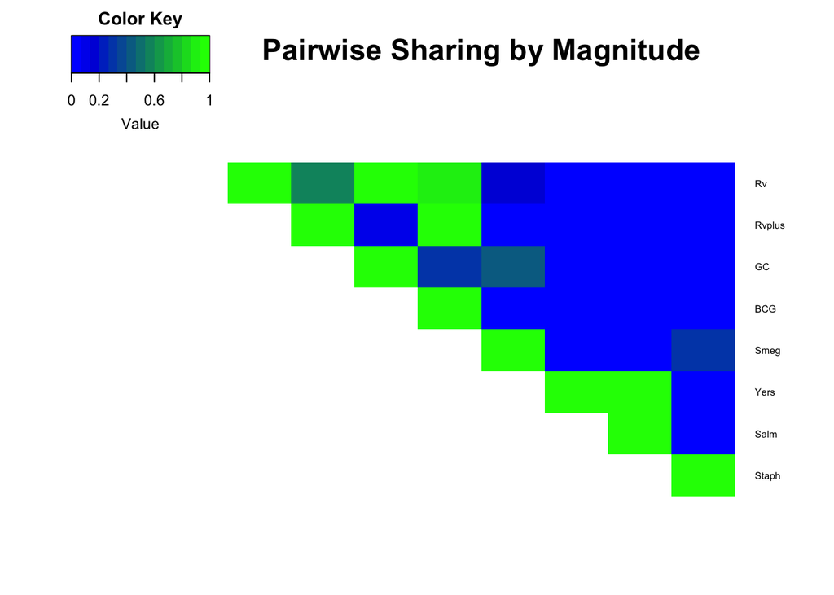

```r
heatmap.2(magheatmap,Rowv=FALSE,Colv=FALSE,
          symm=TRUE,dendrogram="none",density="none",trace="none",#col=redblue,
          col=blue2green,main=paste0("Pairwise Sharing by Magnitude"),
          cexRow=0.6,cexCol=2,cex.main=0.5,#breaks=seq(0.35,1,0.01),
          labCol=NA)
```